# Standard deviation

# What is standard deviation?

- Standard deviation is a measure of variability.
- Standard deviation is approximately the **average distance from mean**.

# Mean absolute deviation

- [MAD](https://en.wikipedia.org/wiki/Average_absolute_deviation) is a more intuitive concept. It is the average distance from mean.
- Example data set: 42, 44, 45, 46, 48
- The mean is 45.
- The absolute differences are 3, 1, 0, 1, 3
- Find the average of those absolute differences:
  $$\frac{3+1+0+1+3}{5}=1.6$$
- This says on average the values are 1.6 units away from 45.

# Standard deviation

- Same example data set: 42, 44, 45, 46, 48
- The mean is still 45.
- The **squared** differences are 9, 1, 0, 1, 9
- The [variance](https://en.wikipedia.org/wiki/Variance) equals the average of those squared differences.
  $$\mathrm{variance}=\sigma^2=\frac{9+1+0+1+9}{5}=4$$
- The standard deviation is the square root of the variance.
  $$\mathrm{SD}=\sigma=\sqrt{4}=2$$

# That seems complicated.

- It is. But standard deviation has a super useful property (when $X$ and $Y$ are independent random variables):
  $$\sigma_{X+Y}=\sqrt{(\sigma_X)^2+(\sigma_Y)^2}$$
- That might not look like much, but it is an absolutely essential component to the [central limit theorem](https://en.wikipedia.org/wiki/Central_limit_theorem), which I will try to exemplify.

# Let’s roll 9d12+7d20 repeated 1000 times

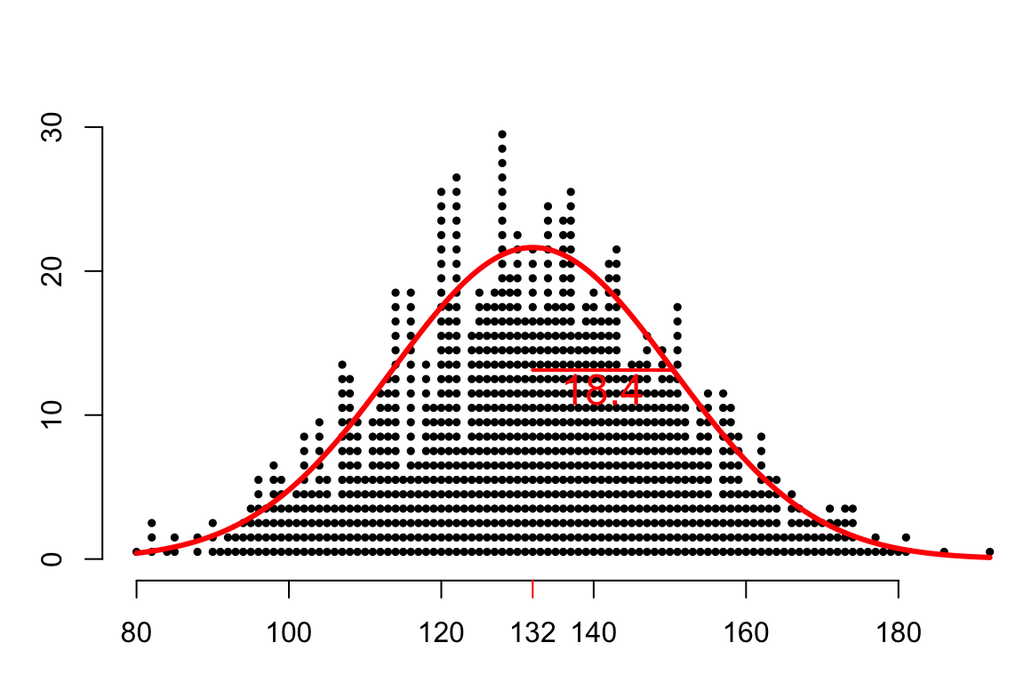

You can predict the red ([normal](https://en.wikipedia.org/wiki/Normal_distribution)) curve before running the simulation.

# How to predict the normal approximation?

- There is a shortcut formula for finding the SD of an [$N$-sided die](https://en.wikipedia.org/wiki/Discrete_uniform_distribution).
  $$\mathrm{SD(1dN)}=\sqrt{\frac{N^2-1}{12}}$$
- So I know the SD of 1d12 and SD of 1d20.
  $$\mathrm{SD(1d12)} \approx 3.45$$
  $$\mathrm{SD(1d20)} \approx 5.77$$
- The super useful property (with a bit of a hand wave) gives me the SD of 9d12+7d20.
  $$\mathrm{SD(9d12+7d20)} =
  \sqrt{9\cdot 3.45^2+7\cdot 5.77^2} = 18.4$$

# What about the center of the normal approximation

- Finding the center (132) is the easy part. It’s based on expected value (means).
- The mean of 1, 2, 3, 4, 5, 6, 7, 8, 9, 10, 11, 12 is $\mu_{1d12}=$**6.5**.
- The mean of 1, 2, 3, 4, 5, 6, 7, 8, 9, 10, 11, 12, 13, 14, 15, 16, 17, 18, 19, 20 is $\mu_{1d20}=$**10.5**.
- $9\cdot6.5+7\cdot10.5 = 132$

# But how would you know to use a **normal** approximation

- “Totals and means are normally distributed!”
- “Totals and means are normally distributed!”
- “Totals and means are normally distributed!”
- *As long as those totals or means have enough bits getting added together and those bits are independent. And there are probably some other disclaimers… but for now…*
- “Totals and means are normally distributed!”
- It does not matter what the underlying distributions are. If each repetition involves adding together (or averaging) a bunch of [independent random variables](https://en.wikipedia.org/wiki/Independent_and_identically_distributed_random_variables), you can expect the totals (or means) of the repetitions to be normally distributed.

# What?

- Standard deviation is a measure of spread (variability).
- Standard deviation is very similar to the **average absolute deviation**.
- The formula for standard deviation:
  $$\sigma = \sqrt{\frac{\sum
  (x-\mu)^2}{n}}$$
- Standard deviation is a kind of complicated statistic to calculate, but we still use it because it is useful.
- Specifically, SD is a key element to the [central limit theorem](https://en.wikipedia.org/wiki/Central_limit_theorem), which is probably the most important concept in Statistics.

# Estimating SD from a histogram

- Let’s say we have three different distributions: a bell, a uniform, and a bimodal.
- They all sit between 200 and 260, so their ranges are approximately 60.

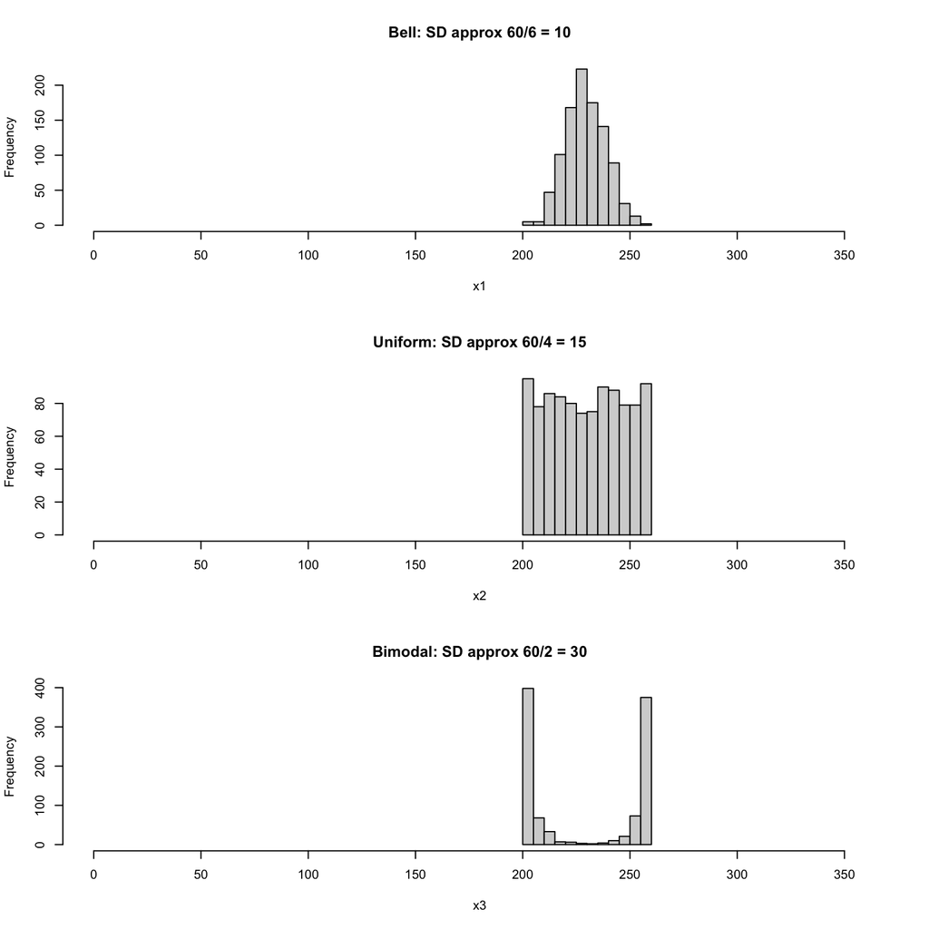

# Bessel’s correction

- When you are estimating the population’s standard deviation from a sample’s standard deviation (and the pop mean is unknown), we use the [Bessel correction](https://en.wikipedia.org/wiki/Bessel%27s_correction) to make a “best-guess” estimation.
- In short, divide by $n-1$ instead of $n$ in the SD formula.
- This is usually just called the sample standard deviation formula.

$$s =
\sqrt{\frac{(x-\bar{x})^2}{n-1}}$$

- Back to our example: 42, 44, 45, 46, 48
- The sample mean is still 45. $\bar{x}=45$
- The squared deviations are still 9, 1, 0, 1, 9.
- But now, the sample variance:
  $$\frac{9+1+0+1+9}{5-1} = 5$$
- And so,
  $$s=\sqrt{5}=2.236$$
- Notice that $s>\sigma$. With the same numbers, the Bessel correction will increase the calculation.

# Will that all be on the test?

- No.
- Really, standard deviation should be review from Algebra 1.
- Massachusetts’ Algebra 2 framework does not require much focus on standard deviation. The only specific learning objective that mentions standard deviation is more to do with finding normal probabilities. We will come back to this later.
  - *S-ID.A.4: Use the mean and standard deviation of a data set to fit it to a normal distribution and to estimate population percentages. Recognize that there are data sets for which such a procedure is not appropriate. Use calculators, spreadsheets, and tables to estimate areas under the normal curve.*